# Replicating and extending analysis from Goodman (2014)

Owen Morgan

March 21, 2024

## Load data

Load the data.

```r
## Load handedness.dta (replicate_dir/lib/1_load/load_replication_data.R)
handedness_dta <- load_replication_data()
## Subset to US sample ('79 and '97 datasets)
## The US dataset is coded as "3", but I will construct it from the component sample
## so that I can filter them later.
## '79 dataset: coded as 4. '97 dataset: coded as 5
hand <- handedness_dta %>% filter(sample %in% c(4, 5)) ## 11,715 observations (as expected)
```

Inspect the data.

```r
## Inspect handedness.dta
hand |> group_by(lefty, sample) |> count() # handedness coded in binary as 0 (right) or 1 (left)
```

| lefty | sample | n |
| --- | --- | --- |
| 0 | 4 | 4808 |
| 0 | 5 | 5181 |
| 1 | 4 | 724 |
| 1 | 5 | 1002 |

```r
hand |> group_by(leftness, sample) |> count() # handedness coded in binary as 0 (right) or 1 (left)
```

| leftness | sample | n |
| --- | --- | --- |
| 0.00 | 4 | 4808 |
| 0.00 | 5 | 4980 |
| 0.25 | 5 | 201 |
| 0.50 | 4 | 121 |
| 0.50 | 5 | 395 |
| 0.75 | 5 | 48 |
| 1.00 | 4 | 603 |
| 1.00 | 5 | 559 |

Right- versus left-hander groups can be constructed by taking those with handedness scores of 0 (right handed) versus those with handedness scores of 1 (left handed). This will approximate a comparison of strong right versus strong left handers (imperfectly, because the NLSY79 dataset only includes a binary ‘right or left’ measure). Goodman’s original analysis compared right handers (coded as 0) to non-right handers (including those with any handedness score between 0 and 1); this analysis is reproduced in the codebook as well.

The occupation codes in the variable “occ” refect the 3-digit 1980 census codes,and the 4-digit 2002 census codes, for the NLSY79 and NLSY97 datasets. Derivatives of ONET ratings are coded in handedness_dta, for each participant’s profession. (e.g., in the variables “occ_creative”, “occ_physical”). “occ_creative” contains a z-scored measure of the degree to which a profession requires originality and inductive reasoning.

Trim to columns we will use.

```r
## Trim to columns we will use
hand <- hand %>% select(sample, leftness, lefty, occ, occ_creative)
```

## Extract prof. counts

Extract counts of artists, architects, and musicians (for meta-analysis).

### Define profession categories for census codes

```r
## Define profession categories (census codes)
codes <- readr::read_csv(here(input_dir, "census_groups.csv"))
```

### Extract counts for each occupation

```r
#### Extract frequencies of left and right handers by profession group

## (1) Code handedness
hand_proc <- code_handedness(hand)

## (2) Extract creative, control counts
counts_proc <- extract_counts(hand_proc, codes)

## Write extracted counts to file
## (Formatted to use as input in ch/analyses/professions/extract.Rmd)
write_counts(counts_proc)
```

## Analyze

### Replicate analysis of difference in job-required creativity by handedness

In each sample (NLSY79, NLSY97, and the combined US sample), calculate the effect of handedness on profession creativity ratings. (Originality, Inductive Reasoning).

Goodman reported that, in the US sample, left handers’ had professions with lower mean Originality and Inductive Reasoning.

Goodman’s cleaned dataset includes a variable “occ_creative” which contains a score combining ONET’s ratings for originality and inductive reasoning for each profession. This score was z-scored across all subjects in each sample. This is the score that Goodman reported was lower in left handers, in the US sample.

This codebook replicates Goodman’s finding, and adds a comparison of strong versus mixed handedness. Handedness was assessed differently in each of the two component samples, so each sample is run separately as well as combined. Additionally, the correlation between profession creativity and proportion of left handers is tested.

In all analyses, a positive effect size indicates a right- or strong-hander advantage. P-values are from a t-tests assuming equal variance.

Replicating Goodman's Originality/Inductive reasoning analysis

| sample | n1 | n2 | m1 | m2 | es_type | lower | effect | upper | p | measure | notes |
| --- | --- | --- | --- | --- | --- | --- | --- | --- | --- | --- | --- |
| R/L |  |  |  |  |  |  |  |  |  |  |  |
| NLSY79 | 4,483 | 658 | 0.004 | −0.027 | Cohen's D | −0.05 | 0.032 | 0.114 | 0.443 | Originality/Inductive reasoning |  |
| NLSY97 | 4,088 | 958 | 0.021 | −0.091 | Cohen's D | 0.042 | 0.113 | 0.183 | 0.002 | Originality/Inductive reasoning |  |
| US | 8,571 | 1,616 | 0.012 | −0.065 | Cohen's D | 0.025 | 0.078 | 0.131 | 0.004 | Originality/Inductive reasoning |  |
| SR/SL |  |  |  |  |  |  |  |  |  |  |  |
| NLSY79 | 4,483 | 547 | 0.004 | −0.006 | Cohen's D | −0.078 | 0.011 | 0.099 | 0.813 | Originality/Inductive reasoning |  |
| NLSY97 | 4,088 | 436 | 0.021 | −0.147 | Cohen's D | 0.071 | 0.17 | 0.269 | 0.001 | Originality/Inductive reasoning |  |
| US | 8,571 | 983 | 0.012 | −0.069 | Cohen's D | 0.016 | 0.082 | 0.148 | 0.015 | Originality/Inductive reasoning |  |

### Test correlation between profession creativity and incidence of left handedness

```r
#### Use lm
## percent_left ~ occ_creative (for each profession); weights = professions

#### Prepare dataframe
sub <- hand_proc %>% filter(rl_sm == "SR/SL")
cor_data <- find_occ_counts(sub)
```

```r
#### Test weighted Pearson correlation
## Column "correlation" is the estimated pearson's correlation coefficient
cor_pearson <- weights::wtd.cor(cor_data$percent_left, cor_data$occ_creative, weight = cor_data$n_total)
cor_pearson %>% as_tibble() |> pretty_table()
```

| correlation | std.err | t.value | p.value |
| --- | --- | --- | --- |
| −0.083 | 0.036 | −2.296 | 0.022 |

## Visualize

### Prepare data

The NLSY79 dataset is coded in tables as “4,” the NLSY97 as “5.” The union of the two datasets is called the “US sample.”

```r
## Define handedness comparison
rl_sm_var <- "SR/SL"
rl_sm_label <- "srsl"
```

```r
## Define subset of data to visualize (handedness comparison)
sub <- hand_proc %>%
  select(sample, rl_sm, handedness, occ, occ_creative) %>%
  filter(rl_sm == "SR/SL") %>%
  ## Make handedness a factor
  mutate(handedness = as.factor(handedness)) %>%
  ## Add variables for creativity score quartile, decile
  mutate(quartile = as.factor(ntile(desc(occ_creative), 4))) %>%
  mutate(decile = as.factor(ntile(desc(occ_creative), 10))) %>%
  ### Make variable with creativity ranking
  mutate(rank = dense_rank(desc(occ_creative)))
```

Filter out participants with no occupation or no occupation creativity score.

```r
sub <- sub %>%
  ## Remove NAs (unemployed or no occupation score)
  filter(!is.na(occ_creative))
```

The half box plot shows the median and quartile bounds. The dot and line show means and 95% confidence intervals.

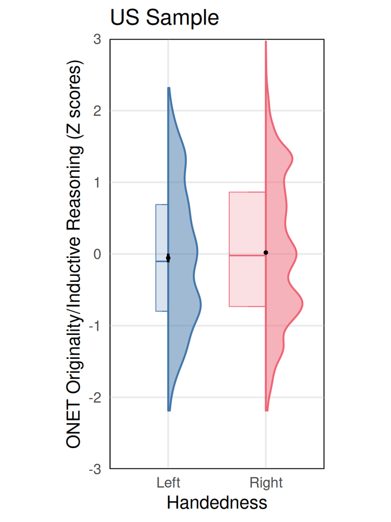

### Proportion of lefties in each quartile

Error bars show 95% confidence intervals (Wilson’s score method). The gray strip shows the percentage of lefties in the whole sample, with 95% confidence bounds.

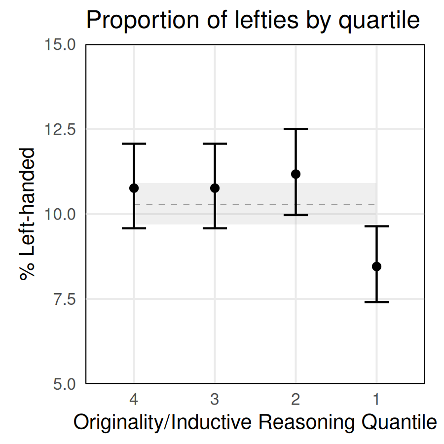

| Quantile | n | n (left) | n (right) | % left | 95% CI |
| --- | --- | --- | --- | --- | --- |
| 1 | 2,389 | 202 | 2,187 | 8.46 | [7.41, 9.64] |
| 2 | 2,389 | 267 | 2,122 | 11.18 | [9.97, 12.5] |
| 3 | 2,388 | 257 | 2,131 | 10.76 | [9.58, 12.07] |
| 4 | 2,388 | 257 | 2,131 | 10.76 | [9.58, 12.07] |

### Quartile stats

```r
## Compare proportion of lefties in top quartile to proportion in lower quartiles
top <- counts |> filter(quantile == 1)
bottom <- counts |> filter(quantile != 1)

x1 <- top$n_left
n1 <- top$n_right
x2 <- sum(bottom$n_left)
n2 <- sum(bottom$n_right)

M <- as.table(rbind(c(x1, n1), c(x2, n2)))
dimnames(M) <- list(group = c("top", "bottom"),
                    handedness = c("left","right"))

Xsq <- chisq.test(M)
tidy(Xsq) |> pretty_table()
```

| statistic | p.value | parameter | method |
| --- | --- | --- | --- |
| 11.338 | 0.001 | 1 | Pearson's Chi-squared test with Yates' continuity correction |